# An Introduction to ggplot2

Bret Larget

Professor Jessi Cisewski Kehe contributed to these lecture notes.

- Note that when the `library(tidyverse)` command is executed, several output lines are written to the console.
- A set of lines indicate which packages have been “attached”, meaning that the commands and data within each of these packages is now available
- Three key packages are:
  - **ggplot2** for graphics which we learn about this week
  - **dplyr** for transforming data which we will use a bit of this week, but learn about in detail next week
  - **readr** for reading data which we will use this week also, but examine in more detail later in the course.
- There is also an ominous-looking set of lines about “Conflicts” printed.
  - These lines may make you think that an error has occurred, but all is well.
  - These are just a warning that a couple functions in the **dplyr** package have the same name as ones in the **stats** package of base R. We just need to be careful when using these functions to specify the one we mean to use.
- The data set we will read in includes dates
- The **lubridate** package in the tidyverse is useful to work with dates, but is not a core package attached with the `library(tidyverse)` command
- We attach it with a separate `library()` call

## Overview

- These notes introduce the Lake Mendota case study and the **ggplot2** package for making plots
- We use data from the Lake Mendota freeze/thaw data set to introduce several types of plots
- Read the [chapter on Lake Mendota](https://bookdown.org/bret_larget/stat-240-case-studies/madison-lakes.html) from the Course Notes and Case Studies for background.
- The R Markdown file for this case study contains all of the code needed to replicate the analysis from lecture.
- However, lecture will skip quickly over the blocks of code that are not directly doing visualization.

## Lake Mendota

- Scientists have been recording the dates when Lake Mendota first closes with ice (at least half the surface is covered with ice) and opens (more than half the surface is liquid water) since the middle of the 1800s.
- In most winters, there is a single uninterrupted period of time from the first time the lake is closed in the winter to the first time it reopens in the spring.
  - Some winters have multiple intervals of closure
- The data set we are using summarizes the raw data with a single row for each winter from 1855–56 through last winter, 2021–22.
  - The variable `year1` is the first year of the given winter.
  - The variable `duration` is the total number of days that Lake Mendota was closed by ice in the given winter. (Note: the word “winter” used here specifies a single season spanning two consecutive calendar years and does not use the endpoints from the winter solstice to the spring equinox, for example.)
- We will first create graphs to examine the question, “How long does Lake Mendota freeze each winter?” with graphical exploration of the variable `duration`.
- Subsequently, we will examine the question, “How has the duration that Lake Mendota freezes each winter changed over time?” by exploring the relationship between `duration` and `year1`.

### Preliminaries

- For you to be able to run the code in this file, you need to put files in proper locations and set the working directory.
- Let `COURSE` represent your course directory.
1. If it does not yet exist, create the folder `COURSE/lecture`.
2. Create the sub-folder `COURSE/lecture/unit2-ggplot2`
3. If it does not yet exist, create the folder `COURSE/data`
4. Download the file `lec-03-lake-mendota.Rmd` into the `unit2-ggplot2` sub-folder.
5. Download the file `lake-mendota-winters-2022.csv` into the `COURSE/data` folder.

## Read the data

- The following R chunk has one line of code that will read in the data set.
- Along with the code I added many comments to explain what is happening.
- Each code chunk begins with three consecutive back ticks at the start of a line.
- The left brace `{` followed by the letter `r` means that the code should be interpreted as r code.
- The name `read-data` is the name of the chunk.
- Naming chunks is helpful when trying to find errors.
  - However, naming is optional; you can not include a name
  - *Be warned that attepting to knit an R Markdown file with duplicate chunk names results in an error.*
- Other knitr options could be set before the right brace `}`, but are not in this example.
- **Note that each R chunk in a file requires a unique name.**
- We will examine `read_csv()` and other functions to read in data later in the semester.
- All characters from the first `#` to the end of the line are comments

```r
## `mendota` is a new object.
## The `=` assigns the loaded data set to the object name `mendota`.
## You will often see `<-' instead as the assignment operator.
##   I use `=` almost all the time, but `<-` is more common.
## read_csv() is a function in the tidyverse for reading in .csv files.
## There is a base R function named read.csv(). Use read_csv() instead.
## If you use read.csv(), character variables get changed to factors
##   and variable names might get changed.
## The argument to read_csv() is a path to the file with the data
## The '..' means go up a directory
## Use a '/' after a directory
##   Windows uses backslashes, but slashes work in R for any computer system.
##   We want to write code that is reproducible on any computer, so stick with '/'.
## The result of the code below is to create a data frame named mendota
##   by reading in the data in the file.
### COURSE/data contains the data file
### COURSE/lecture/unit2 is your working directory
mendota = read_csv("../../data/lake-mendota-winters-2022.csv")
```

- After reading the data with `read_csv()`, a summary is printed to the console which:
  - specifies the number of rows and columns in the data set
  - the delimiter from the data file which separates fields (columns), here, a comma
  - the number of each type of column
  - each column in the data set is a **vector** which we learned about last week.
- Here, there is:
  - one column with character data (`chr`)
  - three with numerical data (`dbl`, which is short for “double”, which means numerical data stored in the computer as a double precision floating point number)
  - two columns with dates
- Note that the base R function `read.csv()` also reads in the data, but is not as nice as `read_csv()`.
  - For example, `read.csv()` does not recognize the columns with dates as such and treats them as character vectors which will lead to problems when we want to work with them as dates.
- If you are an experienced R user used to using `read.csv()`, break the habit and use `read_csv()` instead.

### Checking the Data

- After reading in a data set, I often examine it by clicking on its name in the “Environment” tab in the upper right panel.
- The data will then be viewable in a tab in the upper left panel.
  - It is a good idea to see if the data looks like what you expected
- There are other commands to examine the structure of the data more carefully.
- The command `spec()` is part of the tidyverse and displays how each variable is specified after reading in.
  - R tries to guess the type of each variable
  - If wrong, you can read in the data again, specifying the type of each column
  - The output from `spec()` can be used to copy, paste, and edit to ensure each column’s data type is read in correctly.
  - For this data set, the guesses are all correct and no changes are required.
- **Note: once you have modified a data set, `spec()` may no longer work.**

```r
spec(mendota)
```

## ggplot2

- The **tidyverse** package **ggplot2** is based on a *grammar of graphics* (what the **gg** in **ggplot2** stands for).
- Graphs are based on the following general principles:
  - there is a *mapping* between variables in a data set and various *aesthetics* of the plot
  - *geometries* determine how various aesthetics are represented in the plot
  - a complicated plot may be built by adding several *layers* to the plot
  - additional commands affect other aspects of the plot, such as scales, axes and their annotation, and so on
- The code in the **ggplot2** is a language which implements the grammar of graphics.
- The advantages of having a language for graphs include:
  - *Flexibility*: — the user has a rich language to create a variety of plots which may be customized in countless ways
  - *Reproducibility*: — Code to create graphs may be reused.
  - *Scalability*: — Code for a single graph may be used with iteration to create many graphs

## Plots

- We will first examine a number of plots for visualizing a single quantitative variable.
- Then, we will look at scatter plots to examine relationships between two quantitative variables.
- Additional variables may be shown on a scatter plot via color, shape, size, and other aesthetics, or by breaking a plot into multiple sub-plots by the groups in a categorical variable.

### One-variable Plots

- The variable *duration* is the number of days that the surface of Lake Mendota was at least 50% closed by ice each winter.
  - I may use the shorthand *frozen* to mean the same thing informally.
- This variable can be displayed with many different types of graphs.
- Every plot we make using the **ggplot2** package starts with the function `ggplot()` which takes the name of a data frame as its first argument.
- Then, new layers can be added to the plot.
- This almost always includes at least one geometric element, a function that begins with `geom_` followed by a descriptive name.
- Most plots will include multiple layers to add labels, modify previous layers, add more features to the plot, and so on.
- Note that the `+` sign must be at the end of each line, not the beginning of the line.
- (If not, R thinks you were done adding layers the first time there is not an `+` at the end.)

#### Histograms

- A histogram is a bar plot for summarizing a **single quantitative variable**
  - The number line is divided into intervals which span the range of data values
  - Typically, each interval is the same width
  - The height of the each is proportional to the number of values in the corresponding interval
  - Some convention needs to be followed to determine where values on the boundary are counted
  - Unlike a bar plot of a categorical variable, there is no space between adjacent bars

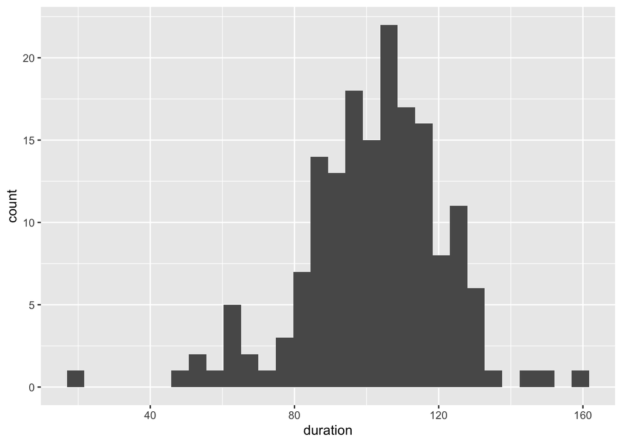

```r
ggplot(data = mendota, mapping = aes(x = duration)) +
  geom_histogram()
```

#### Naming Arguments

- We will use `ggplot()` very often and will soon memorize that the first argument is `data` and the second is `mapping`
  - We can leave off these argument names and create the same plot with

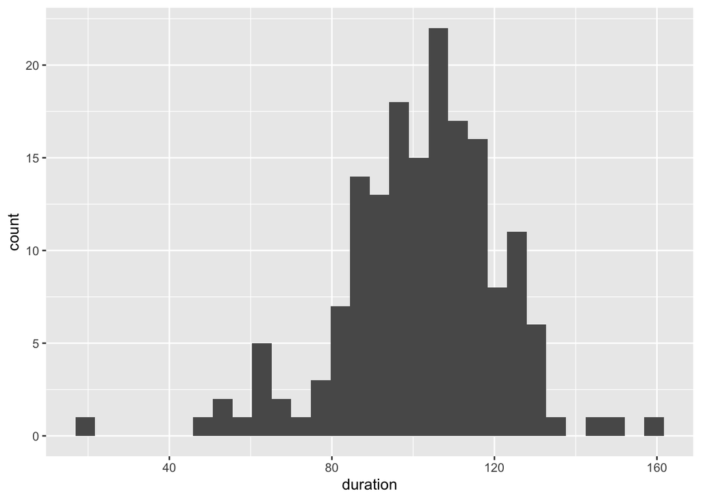

```r
ggplot(mendota, aes(x = duration)) +
  geom_histogram()
```

- The code chunk above contains a single command split over two lines to create the plot
- Each plot made with **ggplot2** typically consists of several *layers*
  - the commands for each later are separated by a `+` sign
  - it is good practice to make your code more easily readable to place each layer on a separate line
  - Each line except for the last ends with a `+`
  - R will continue to read additional lines to add to the command if the typed command so far is “left hanging” with a `+` meaning more is to come.
- The command `ggplot()` is always used to create a new plot.
  - the first argument to `ggplot()` is named `data` and is set to be the name of the data set which contains the data to be plotted
  - the second argument to `ggplot()` is named `mapping`, which describe a mapping between *variables* in the data set and aesthetics of the graph used to display the corresponding variable.
  - Aesthetics be things such as a location on the `x` or `y` axes, a color, a shape, a size, or more.
  - In this simple plot, the only variable is `duration` and it is displayed in the plot by locations on the x axis by setting `mapping` to be `aes(x = duration)`.
  - the value of `mapping` is always set using the function `aes()`.
- The next part of the command is `geom_histogram()` which determines which “geometry” is used to display the corresponding variables.
  - `geom_histogram()` creates a histogram

##### Improving the histogram

- There are may ways to improve the histogram:
  - The bin endpoints are not nice numbers
  - The bin widths are not nice numbers
  - It is hard to see where one bin ends and another begins; different colors for the boundary and interior would help
  - Axis labels use internal variable names, not names which would be easier for others to read and understand
  - There is no title to the plot
- The next histogram changes:
  - the labels with `ggtitle()`, `xlab()`, and `ylab()`
  - the widths of the bars with the `binwidth` argument
  - the boundaries where the bars are set with the `boundary` argument
  - the color of the bar interiors with the `fill` argument
  - the color of the bar outlines with the `color` argument

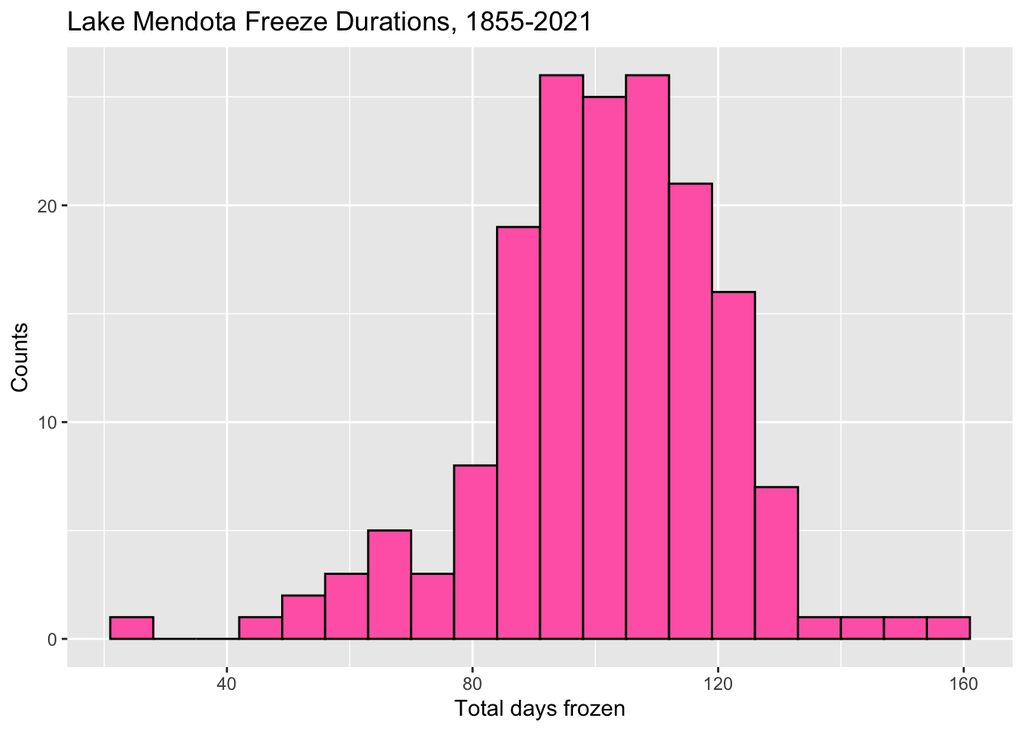

```r
ggplot(mendota, aes(x = duration)) +
  geom_histogram(fill = "hotpink",
                 color = "black",
                 binwidth = 7,
                 boundary = 0) +
  xlab("Total days frozen") +
  ylab("Counts") +
  ggtitle("Lake Mendota Freeze Durations, 1855-2021")
```

##### Bin endpoints

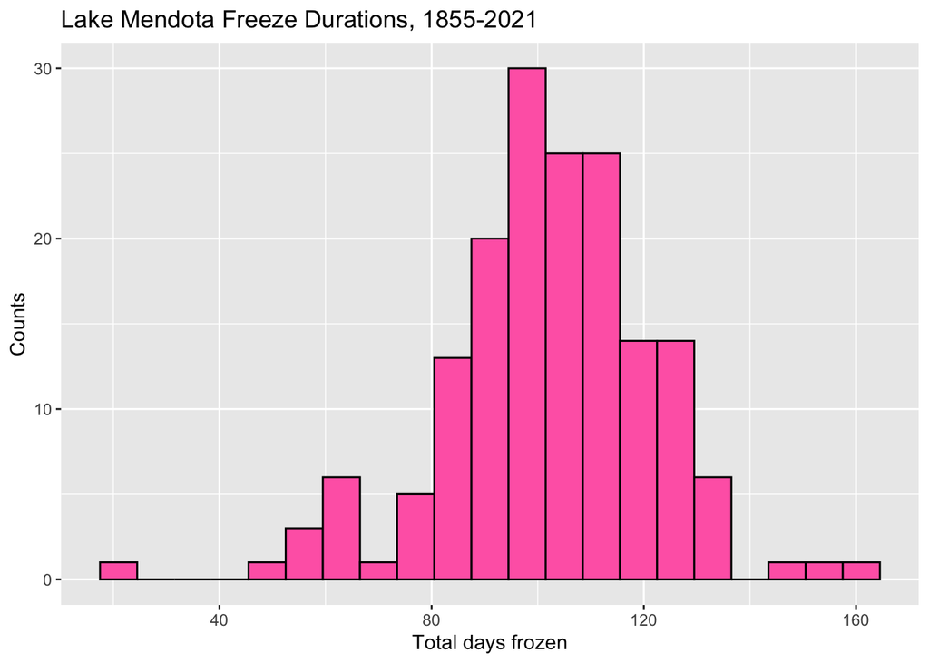

```r
ggplot(mendota, aes(x = duration)) +
  geom_histogram(fill = "hotpink",
                 color = "black",
                 binwidth = 7,
                 center = 0) +
  xlab("Total days frozen") +
  ylab("Counts") +
  ggtitle("Lake Mendota Freeze Durations, 1855-2021")
```

#### Where to specify the data and aesthetics

- Any data and aesthetics mapping set within `ggplot()` carry over to all additional layers (some of which will ignore them)
- A layer can modify these by using `data` or `mapping` arguments in the command to create the layer.

#### Density Plot

- A histogram is just one example of a “geom” to display a single quantitative variable
- An alternative is a density plot which lessens the visual effects due to arbitrary choices to determine bin endpoints.
- A density plot can be thought of as a smoothed histogram.
- We can display the same data using density plot using `geom_density().`

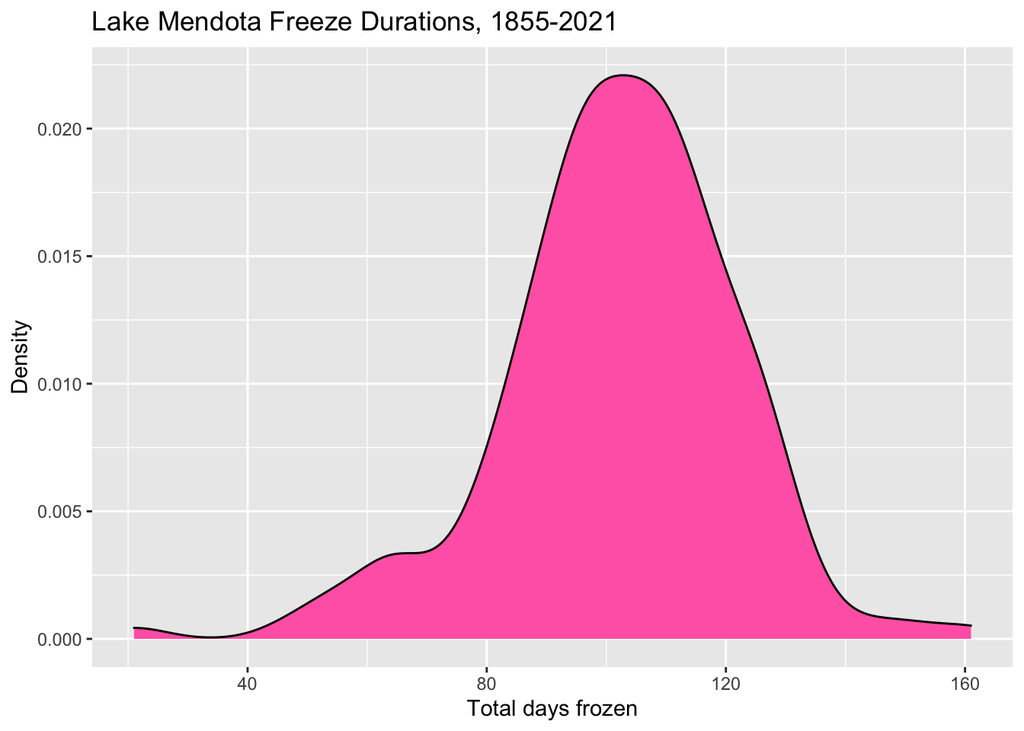

```r
ggplot(mendota) +
  geom_density(aes(x=duration),
               fill="hotpink",
               color="black") +
  xlab("Total days frozen") +
  ylab("Density") +
  ggtitle("Lake Mendota Freeze Durations, 1855-2021")
```

- In a density plot, the “Count” on the y axis is replaced by “Density”
- The numerical values are scaled so that the total area under the curve is equal to one.
- Density plots smooth away the harsh transitions of a histogram, but lose the capability to display the raw data counts.
  - From a histogram with counts, we know how many observations are in each interval and can determine the total number of observations in the data
  - A density plot only shows relative amounts of data and loses this sample size information.
- Histograms and density plots are the most common ways to display the distribution of single quantitative variables, but others exist.
  - See the **ggplot2** cheat sheet for more examples.

#### Boxplots

- A boxplot is a graphical depiction of some key quantiles of a distribution of numerical values.
  - The minimum (smallest value)
  - The first quartile (25th percentile or 0.25 quantile)
  - The median (the middle value / 50th percentile / 0.5 quantil)
  - The third quartile (75th percentil of 0.75 quantile)
  - The maximum
- Typical boxplots often also identify potential outliers which are extreme values below the first quartile or above the third quartile.
- This code chunk creates a vertical boxplot of `duration` by mapping it to the aesthetic `y`.
- See what happens if we use `x` instead?

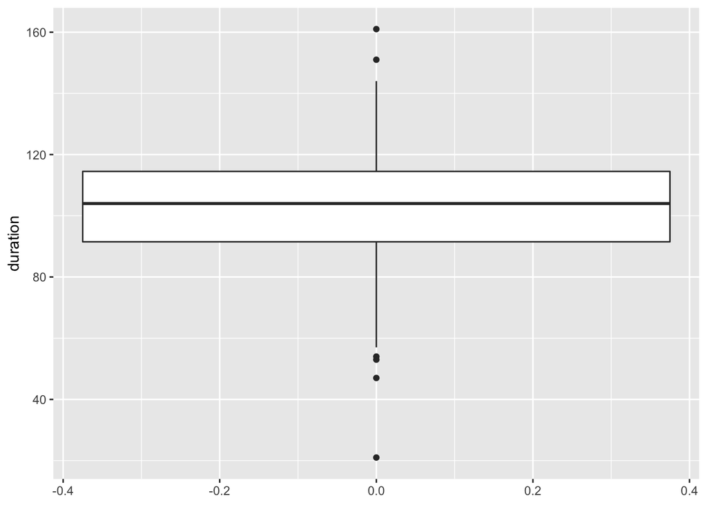

```r
ggplot(mendota, aes(y = duration)) +
  geom_boxplot()
```

- The box outlines the middle 50% of the observations
  - the bottom of the box (i.e., the lower hinge) gives the 25th percentile (the first quartile, Q1)
  - the middle bar give the median (the 50th percentile)
  - the top of the box (i.e., the upper hinge) gives the 75th percentile (the third quartile, Q3)
- The lower vertical line (i.e., the lower whisker) reaches down to the minimum value of the observations, but will not drop below Q1 - 1.5 x IQR, where IQR = Q3 - Q1 is the inter-quartile range.
- Similarly, the higher vertical line (i.e., the upper whisker) reaches up to the maximum value of the observations, but will not go above Q3 + 1.5 x IQR.
- Any points plotted below or above the vertical lines indicate observations that are below or above the noted ranges. These points may be considered potential outliers.
- The number line on the x axis is meaningless and arbitrary.

#### Side-by-side box plots

- We rarely use box plots to summarize a single variable as the graphical summary from a histogram or density plot is so much more informative.
- However, boxplots can be very useful when we wish to compare multiple distributions to each other on the same numerical scale
- For example, the variable `decade` partitions each year into the decade associated with its first year.
- This plot shows side by side box plots to help see how freeze durations have changed over time.
- Each boxplot is from 10 or fewer data points
- The `x` variable is set to `as.character(decade)` so that `decade` is treated as categorical and not numerical.

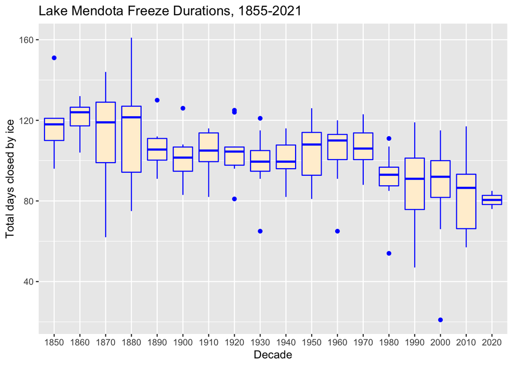

```r
ggplot(mendota, aes(x = as.character(decade), y = duration)) +
  geom_boxplot(fill = "papayawhip",
               color = "blue") +
  ylab("Total days closed by ice") +
  xlab("Decade") +
  ggtitle("Lake Mendota Freeze Durations, 1855-2021")
```

- We see that in the 1800s, a typical freeze duration was nearly 120 days whereas in more recent decades, a typical duration has decreased to under 90 days.

### Two-variable Plots

- We created the side-by-side boxplot by taking a numerical variable, `year1`, and turning it into a categorical variable, `decade`.
- There was no need to do so:
  - We can examine the relationship between `year1` and `duration` directly.

#### Scatter Plots

- A scatter plot summarizes two numerical variables by associating one with the x axis and the other with the y axis and plotting points.
- This R chunk displays a cloud of data points

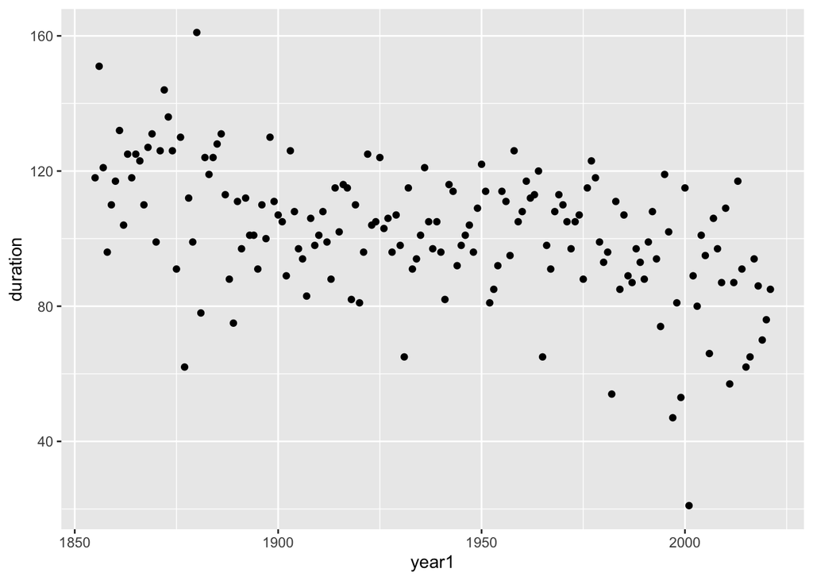

```r
ggplot(mendota, aes(x = year1, y = duration)) +
  geom_point()
```

- When one variable is time, it is often useful to use a “trace plot” instead of a scatter plot by changing the geometry from individual points to line segments which connect consecutive points.

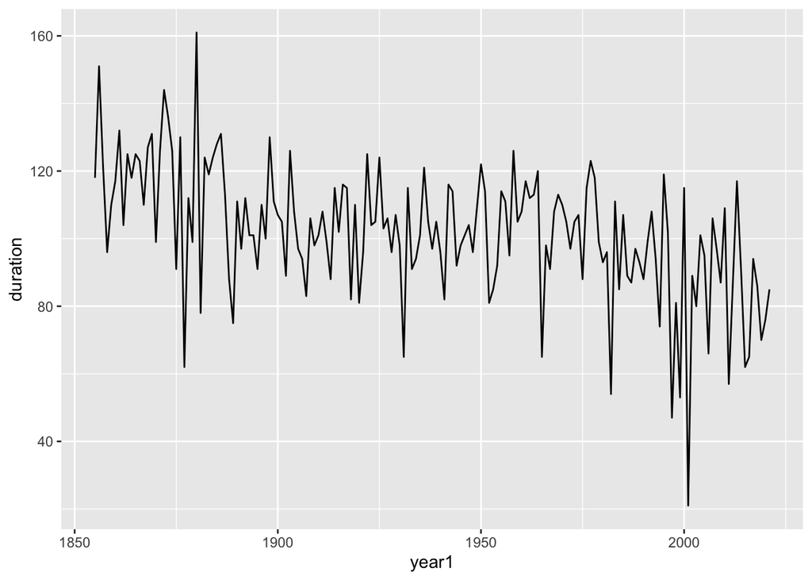

```r
ggplot(mendota, aes(x = year1, y = duration)) +
  geom_line()
```

- This graph makes it easier to see that there is a decreasing trend, but that the actual pattern of decrease is quite noisy with substantial year-to-year variation.
- Another geometry greatly reduces the noise and replaces the actual data values with a smooth curve.

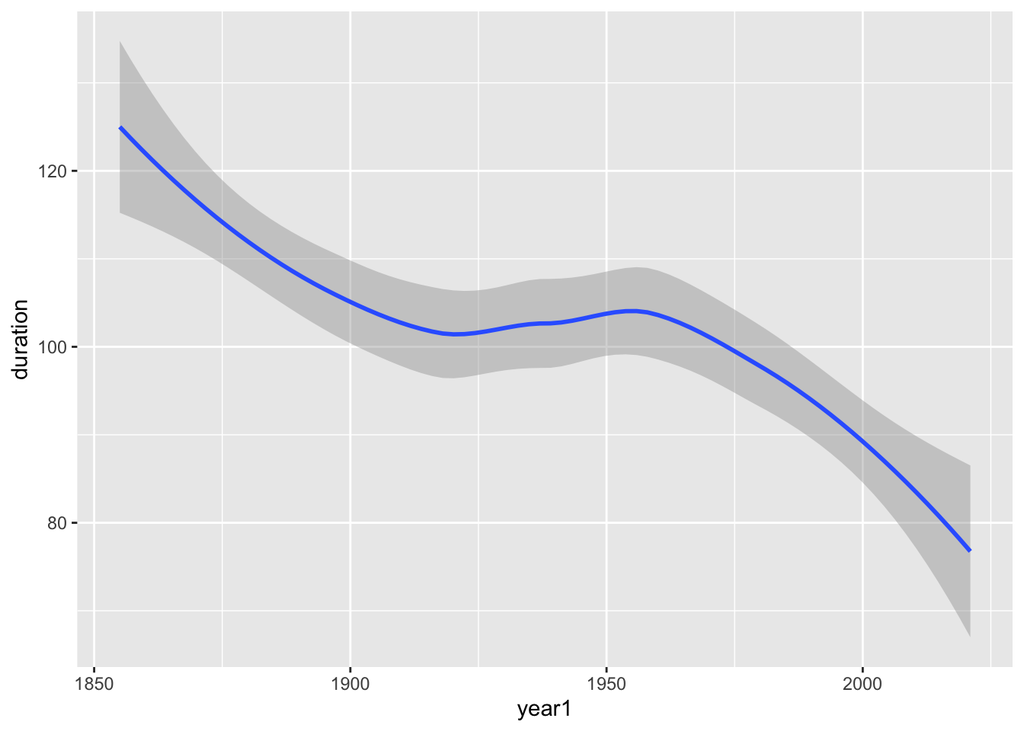

```r
ggplot(mendota, aes(x = year1, y = duration)) +
  geom_smooth()
```

- The default graph produced with `geom_smooth()` draws a ribbon to represent uncertainty in the true value of the estimated trend line.
- We can discard this ribbon by setting the argument `se` (short for *standard error* which we will see later in the course) to be `FALSE`.

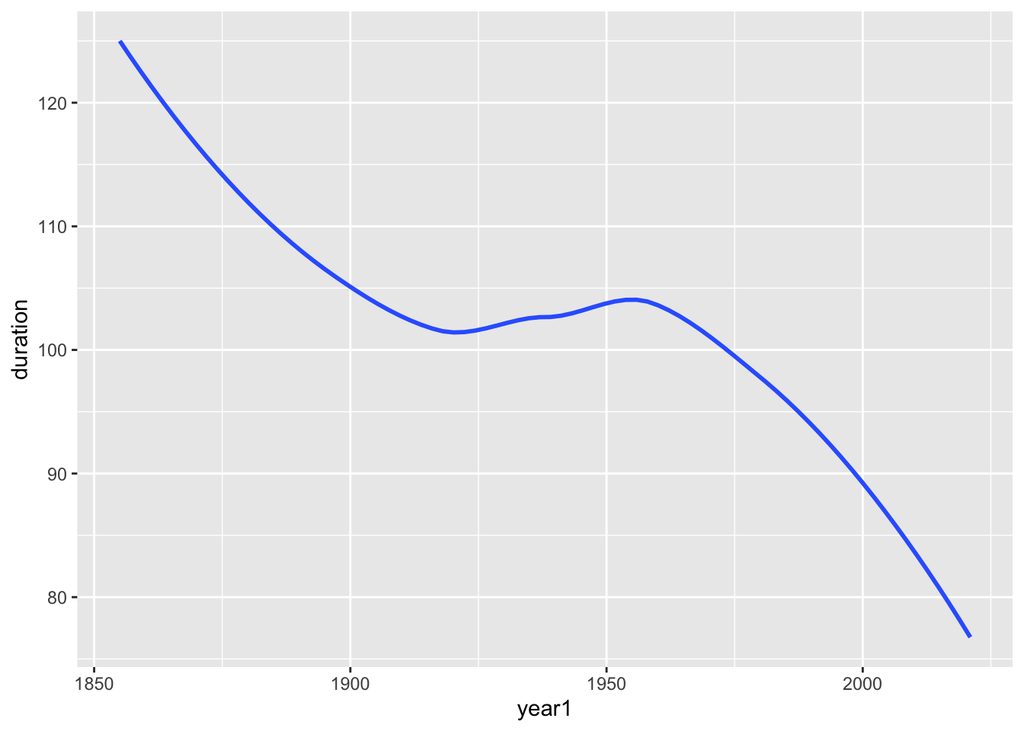

```r
ggplot(mendota, aes(x = year1, y = duration)) +
  geom_smooth(se = FALSE)
```

- After suppressing the year-to-year noise, we see a summarized pattern where the duration with which Lake Mendota has remained closed by ice in a typical year has decreased from over 120 days in 1850 to under 80 days at present.
  - There was a steady decline from 1850 to about 1920, followed by about 30–40 years of with a slight increase on average, followed by a decline at an even faster rate from about 1960 to the present.
  - Perhaps the rate of decrease is becoming steeper.

#### Scatter Plot with a Trend Line Added

- There is no reason to select only one of the previous plots.
- A better graphical display can be obtained by layering multiple pieces of the previous grpahs together.

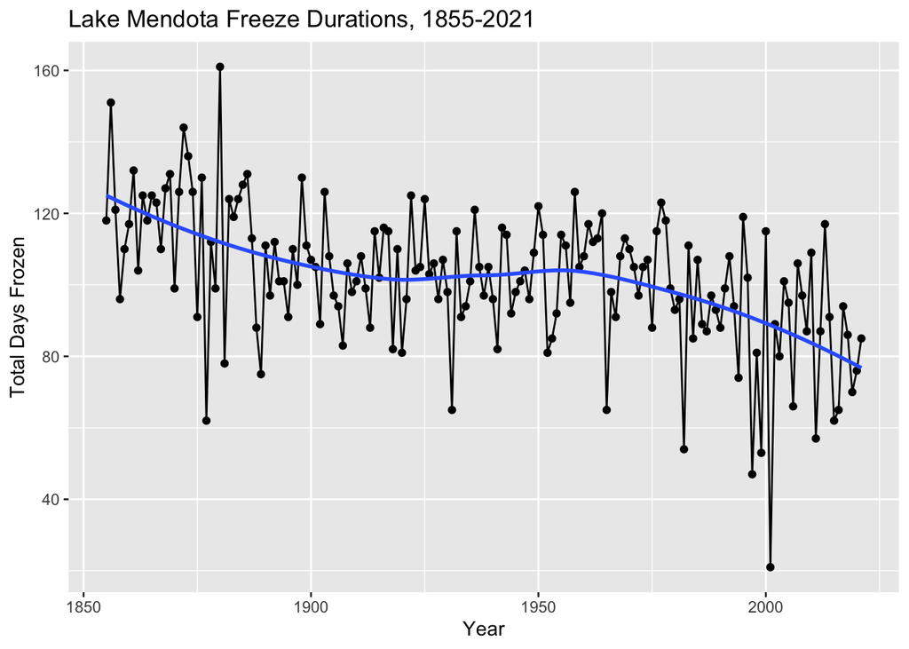

```r
## note setting the aesthetics here in ggplot()
## otherwise, we would need to set in geom_point(), geom_line(), and geom_smooth()
ggplot(mendota, aes(x=year1, y=duration)) +
  geom_point() +
  geom_line() +
  geom_smooth(se=FALSE) +
  xlab("Year") +
  ylab("Total Days Frozen") +
  ggtitle("Lake Mendota Freeze Durations, 1855-2021")
```